# Finding and Fixing Vulnerabilities Using AI – Do not ignore AI

## 3.1 Do not ignore AI

Some organizations and projects want to simply ignore AI, or refuse to use it, or refuse to accept any contributions where AI was used. If the goal of the project is to solely demonstrate what humans can do without AI, that’s fine.

However, if the goal of the project is to be used by humans to solve a real-world problem, refusing AI use is an *extremely harmful* position to take. As Michael Catanzaro notes, “banning good vulnerability reports solely because some portion of the report was generated by AI is unacceptable. AI-assisted vulnerability reports are the new industry standard… Prohibiting issue reports reduces the quality and safety of your software, punishing your users.” [[Catanzaro2026](https://blogs.gnome.org/mcatanzaro/2026/06/08/please-do-not-ban-ai-assisted-issue-reports/)]

Defenders who ignore AI are at a fundamental speed disadvantage. “Defenders… that do not adopt AI coding agents cannot match the speed or scale of AI-augmented threats, regardless of their technical skill.” [[CSA2026](https://labs.cloudsecurityalliance.org/mythos-ciso/)] “Not using AI code analyzers in your project means that you leave adversaries and attackers time and opportunity to find and exploit the flaws you don’t find.” [[Stenberg2026-05a](https://daniel.haxx.se/blog/2026/05/11/mythos-finds-a-curl-vulnerability/)]

The CSA recommends that organizations *require* AI agent adoption by their employees: “Formalize AI agent usage (mostly in the form of coding agents”) as part of all security functions, with mandatory security controls and oversight in place. While defensive AI technology has not yet caught up, these agents empower staff to be effective in the new threat landscape, allowing acceleration beyond “human speed.” Optional adoption programs have not been shown to overcome cultural barriers, while adoption is a limiting factor in achieving the rest of the actions in this table.” [[CSA2026](https://labs.cloudsecurityalliance.org/mythos-ciso/)]

Note that this doesn’t mean that all code must be AI generated or anything like that. AI-generated code can in some cases be terrible for security. However, that’s different than trying to entirely ignore AI.

*Trying to withstand AI-enabled attackers, while refusing to use AI yourself, can only end one way: **compromise**.*

Attackers *prefer* developers who unwisely refuse to use AI to help find and fix vulnerabilities. Attackers are *already* using AI to create multi-step complex attacks that reliably defeat software systems whose developers were not prepared for AI-assisted attacks. The more defenders who won’t use AI, the more systems that can be subverted and the more people who will be harmed.

You *need* to use AI to help find and help fix vulnerabilities if it’s important that the software be secure. Do not bring a knife to a gunfight.

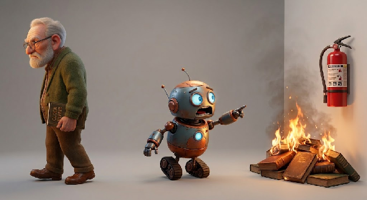

A robot tries to warn a human about a fire, but the human is ignoring the robot

**Quiz**

Q1. What’s a risk if a project bans all AI-assisted vulnerability reports?

1. It has little effect, since attackers rarely rely on AI themselves
2. It reduces the software’s overall quality and safety by rejecting valid reports
3. It automatically violates the terms of the project’s open source license
4. It disqualifies the project from ever receiving CVE identifiers

**Show answer**

Answer: B